# Презентация по лабораторной работе №6

Решение моделей в непрерывном и дискретном времени

Люпп Софья Романовна

1132236039@rudn.ru

Российский университет дружбы народов

2026-11-21

# Информация

## Докладчик

- Люпп Софья Романовна
- студентка группы НКНбд-01-23
- кафедра теории вероятностей и кибербезопасности
- Российский университет дружбы народов им. П. Лумумбы
- [1132236039@rudn.ru]
- https://github.com/srluipp

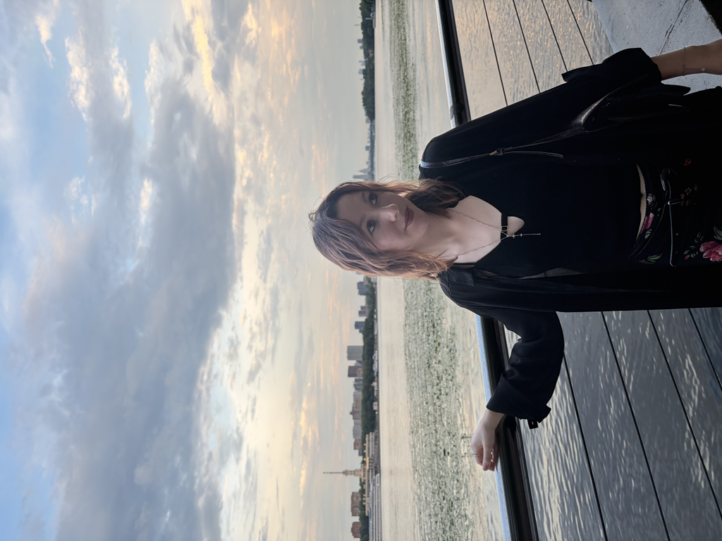

# Вводная часть

## Актуальность

Julia актуальна как инструмент для научных вычислений, финансового моделирования, искусственного интеллекта, вычислений в области инженерии и физики, благодаря своей высокой производительности, простоте синтаксиса и гибкости в работе с массивами и параллельным программированием

## Объект и предмет исследования

Язык программирования Julia и среда JupyterLab

## Цели и задачи

Основной целью работы является освоение специализированных пакетов для решения задач в непрерывном и дискретном времени.

# Выполнение лабораторной работы

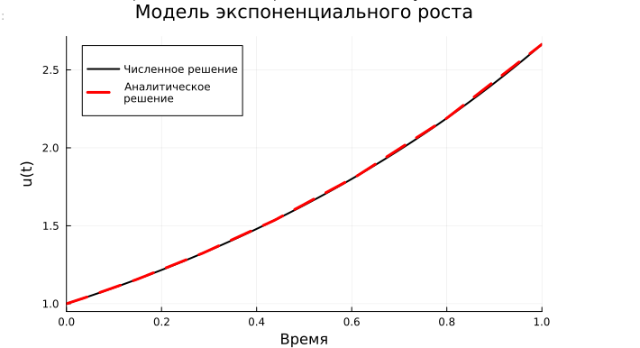

# Выполнение лабораторной работы

(рис. 1).

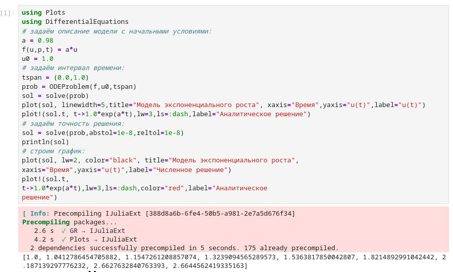

Рисунок 1: модель экспоненциального роста

## Задания лабораторной работы

Строю аттракцион Лоренца. Система описывает движение потоков в плоском слое жидкости постоянной толщины при разложении скорости течения и температуры в двойные ряды Фурье с последующем усечением до первых-вторых гармоник. (рис. 2)

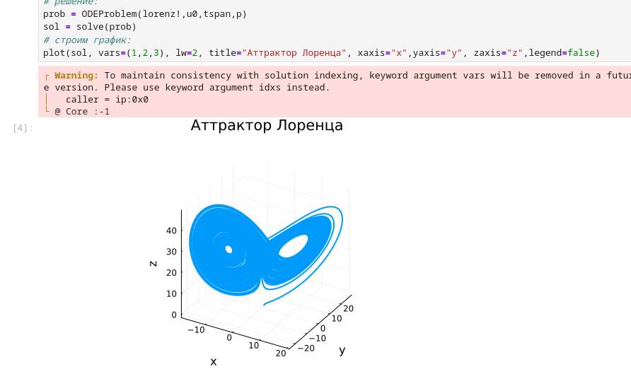

Рисунок 2: Аттракцион Лоренца

## Задания лабораторной работы

Аттракцион Лоренца с отключенной интерполяцией (рис. 3)

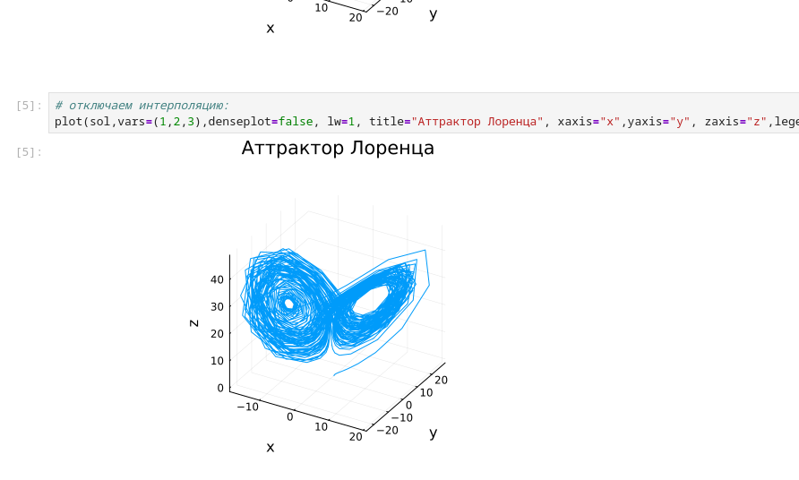

Рисунок 3: Без интерполяции

## Задания лабораторной работы

Модель Лотки–Вольтерры описывает взаимодействие двух видов типа «хищник – жертва»: { ̇𝑥 = (𝛼 − 𝛽𝑦)𝑥, ̇𝑦 = (−𝛾 + 𝛿𝑥)𝑦, где 𝑥 — количество жертв, 𝑦 — количество хищников,𝑡 — время, 𝛼, 𝛽, 𝛾, 𝛿 — коэффициенты, отражающие взаимодействия между видами (в данном случае 𝛼 — коэффициент рождаемости жертв, 𝛾 — коэффициент убыли хищников, 𝛽 — коэффициент убыли жертв в результате взаимодействия с хищниками, 𝛿 — коэффициент роста численности хищников). (рис. 4).

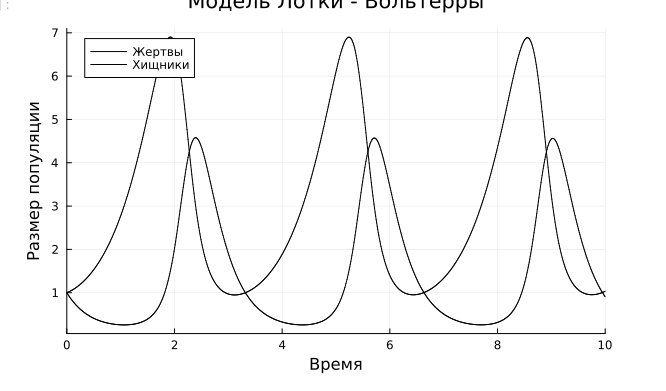

Рисунок 4: Модель Лотки-Вольтерры

## Задания лабораторной работы

[figure not shown]

Рисунок 5: Фазовый портрет

## Задания самостоятельной работы

Реализую и проанализирую модель роста численности изолированной популяции (модель Мальтуса): где 𝑥(𝑡) — численность изолированной популяции в момент времени 𝑡, 𝑎 — коэффициент роста популяции, 𝑏 — коэффициент рождаемости, 𝑐 — коэффициент смертности (рис. Рисунок 6])

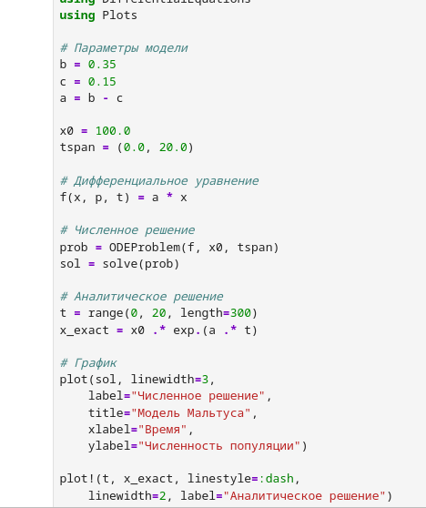

Рисунок 6: Модель Мальтуса

## Задания лабораторной работы

Модель Мальтуса (рис. 7).

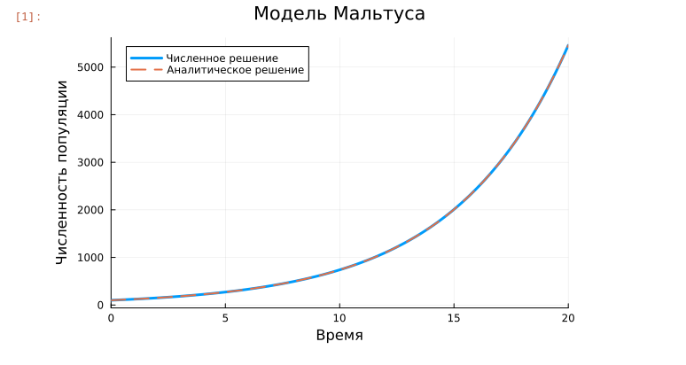

Рисунок 7: График модели Мальтуса

## Задания лабораторной работы

Анимация модели Мальтуса (рис. 8).

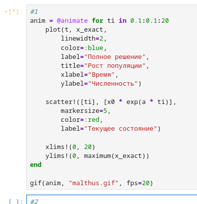

Рисунок 8: Анимация

## Задания лабораторной работы

Анимация модели Мальтуса (рис. 9) .

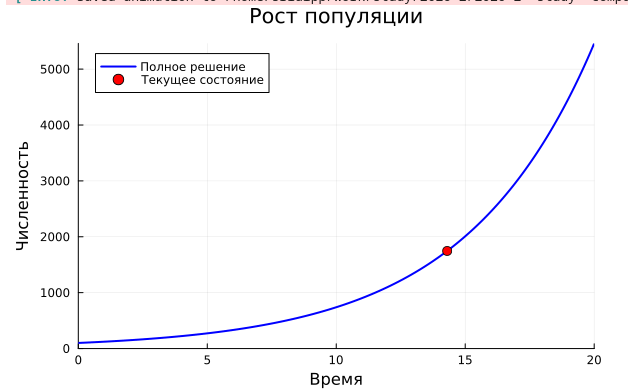

Рисунок 9: ГРафик анимации

## Задания лабораторной работы

Реализую и проанализирую логистическую модель роста популяции, где 𝑟 — коэффициент роста популяции, 𝑘 — потенциальная ёмкость экологической системы (предельное значение численности популяции) (рис. 10).

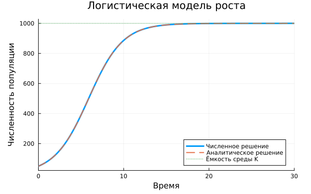

Рисунок 10: Логистическая модель

## Задания лабораторной работы

Анимация логистической модели (рис. 11).

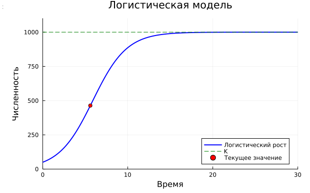

Рисунок 11: Анимация

## Задания лабораторной работы

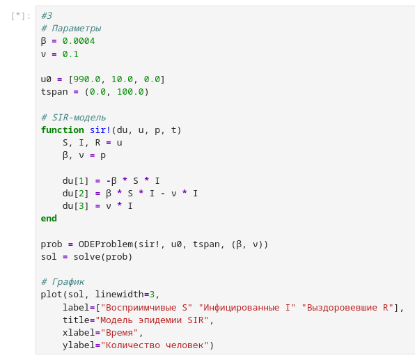

Рисунок 12: Параметры модели

## Задания лабораторной работы

Реализую и проанализирую модель эпидемии Кермака–Маккендрика (SIRмодель), где 𝑠(𝑡) — численность восприимчивых к болезни индивидов в момент времени 𝑡, 𝑖(𝑡) — численность инфицированных индивидов в момент времени 𝑡, 𝑟(𝑡) — численность переболевших индивидов в момент времени 𝑡 (рис. 13)

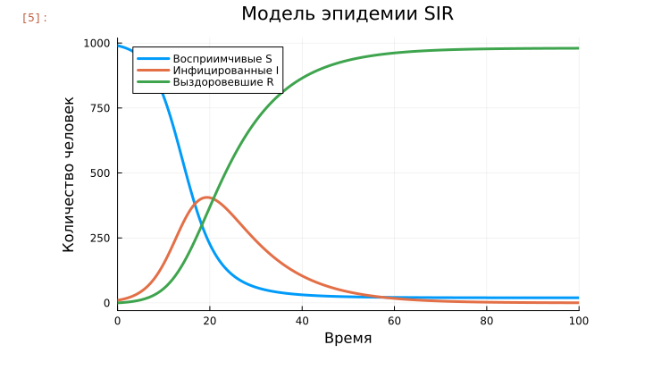

Рисунок 13: Модель Кермака–Маккендрика

## Задания лабораторной работы

Анимация модели Кермака–Маккендрика (рис. 14)

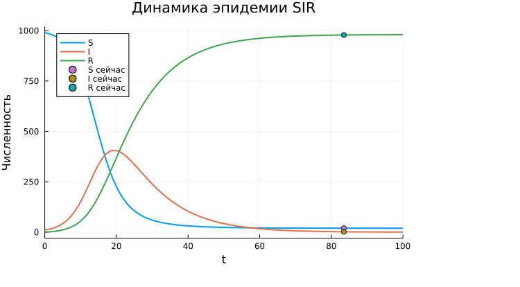

Рисунок 14: Анимация

## Задания лабораторной работы

Реализую график SEIR, как расширение модели SIR (Susceptible-Infected-Removed) по результатам эпидемии испанки (Susceptible-Exposed-Infected-Removed)(рис. 15)

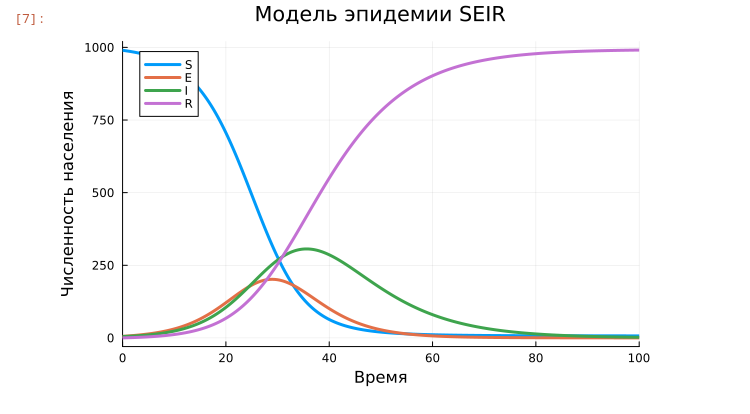

Рисунок 15: SEIR

## Задания лабораторной работы

Код модели SEIR (рис. 16)

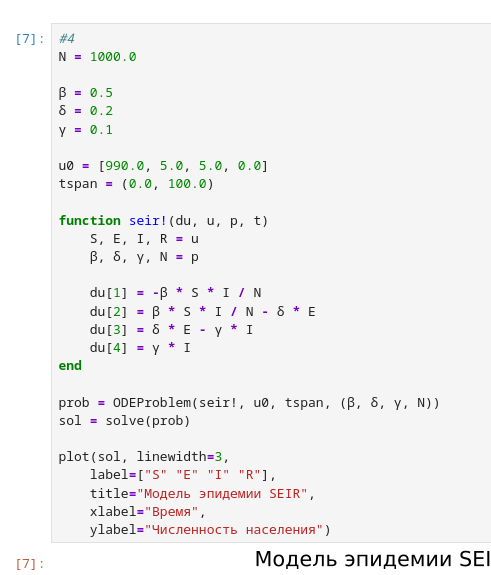

Рисунок 16: SEIR

## Задания лабораторной работы

Код модели SIR (рис. 17)

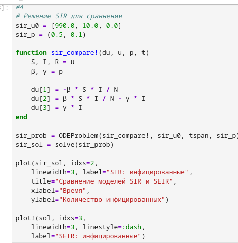

Рисунок 17: SIR

## Задания лабораторной работы

Нахожу точку равновесия для дискретной модели Лотки-Вольтерры и сравниваю аналитическое и численное решения (рис. 18)

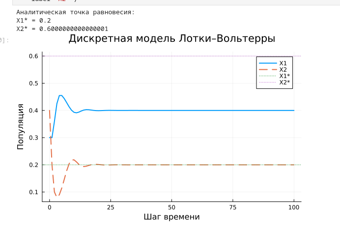

Рисунок 18: Дискретная модель Лотки-Вольтерры

## Задания лабораторной работы

Код модели Лотки-вольтерры (рис. 19)

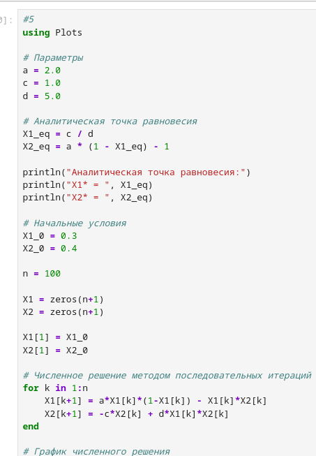

Рисунок 19: Код с параметрами модели

## Задания лабораторной работы

Фазовый портрет дискретной модели (рис. 20)

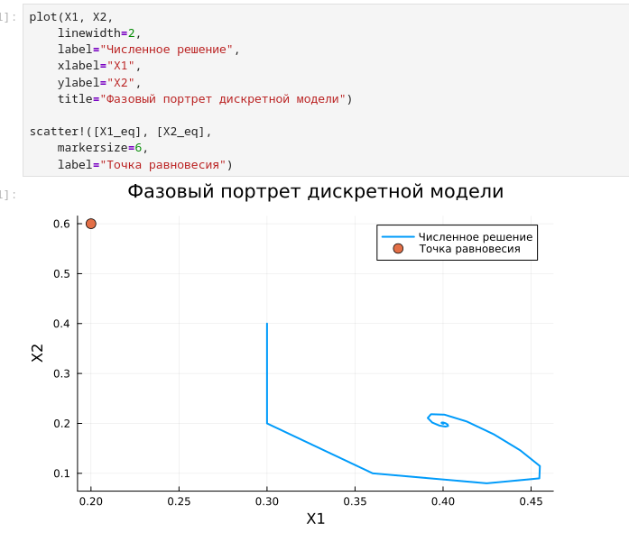

Рисунок 20: Фазовый портрет

## Задания лабораторной работы

Реализую модель отбора на основе конкурентных отношений (рис. 21).

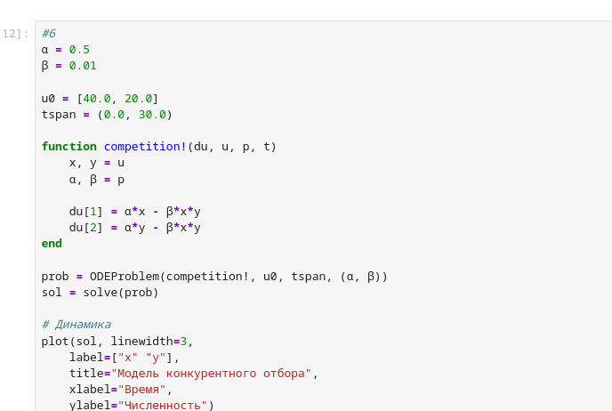

Рисунок 21: Модель отбора код

## Задания лабораторной работы

Модель отбора конкурентных отношений и ее фазовый портрет (рис. 22)

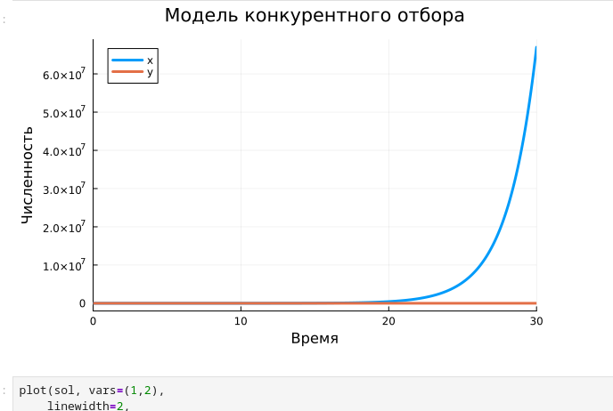

Рисунок 22: Модель отбора

## Задания лабораторной работы

(рис. 23)

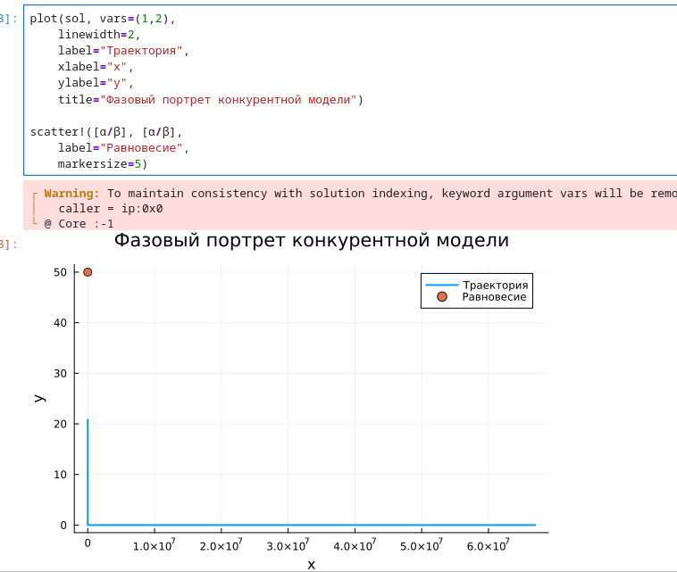

Рисунок 23: Фазовый портрет

## Задания лабораторной работы

Делаю анимацию (рис. 24) .

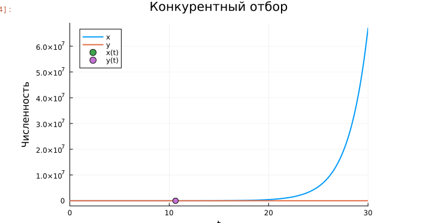

Рисунок 24: Анимация

## Задания лабораторной работы

Реализую модель консервативного гармонического осциллятора, где 𝜔0 — циклическая частота(рис. 25) .

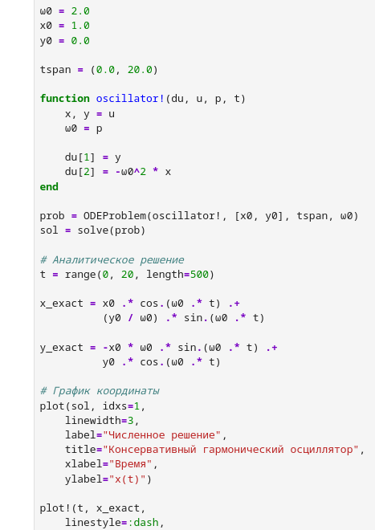

Рисунок 25: Гармонический осциллятор

## Задания лабораторной работы

График гармонического осциллятора (рис. 26).

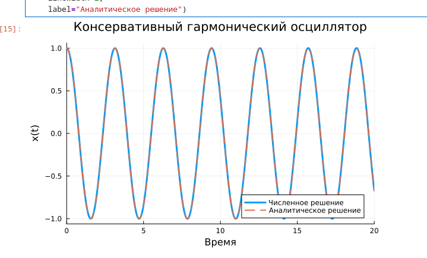

Рисунок 26: График осциллятора

## Задания лабораторной работы

Фазовый портрет осциллятора (рис. 27).

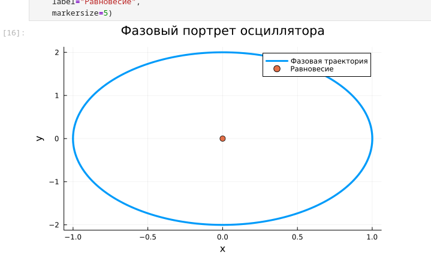

Рисунок 27: Фазовый портрет